# Tugas MPDW

Muhamad Farras Surya Dio Putra

2023-09-02

library

```r
library("forecast")
```

```r
library("graphics")
library("TTR")
library("TSA")
```

#Impor Data

```r
library(rio)
dataset = import("https://raw.githubusercontent.com/farrasdp/mpdw/main/Pertemuan%201/dataset%20tugas.csv")
dataset
```

```
##           Date Returning.Visits
## 1   01/01/2019              277
## 2   01/02/2019              462
## 3   01/03/2019              534
## 4   01/04/2019              437
## 5   01/05/2019              261
## 6   01/06/2019              398
## 7   01/07/2019              550
## 8   01/08/2019              597
## 9   01/09/2019              585
## 10  01/10/2019              538
## 11  01/11/2019              477
## 12  01/12/2019              309
## 13   1/13/2019              386
## 14   1/14/2019              588
```

[output cut: 351 more lines]

#Eksplorasi data

```r
View(dataset)
str(dataset)
```

```
## 'data.frame':    365 obs. of  2 variables:
##  $ Date            : chr  "01/01/2019" "01/02/2019" "01/03/2019" "01/04/2019" ...
##  $ Returning.Visits: int  277 462 534 437 261 398 550 597 585 538 ...
```

```r
dim(dataset)
```

```
## [1] 365   2
```

#Mengubah data agar terbaca sebagai data deret waktu

```r
dataset.ts <- ts(dataset$Returning.Visits)
```

#Menampilkan ringkasan data

```r
summary(dataset.ts)
```

```
##    Min. 1st Qu.  Median    Mean 3rd Qu.    Max.
##   157.0   395.0   508.0   506.2   617.0   866.0
```

#Membuat plot data deret waktu

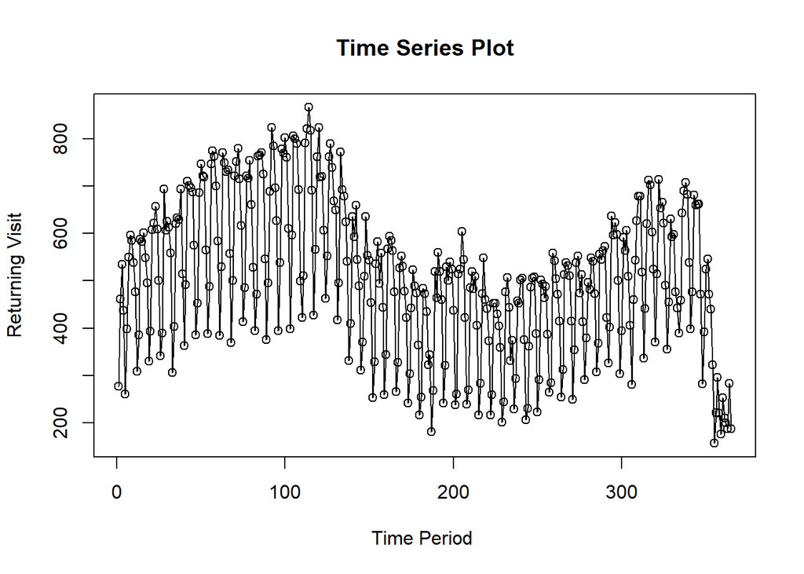

```r
ts.plot(dataset.ts, xlab="Time Period ", ylab="Returning Visit",
        main = "Time Series Plot")
points(dataset.ts)
```

## Single Moving Average & Double Moving Average

### Pembagian Data

Pembagian data latih dan data uji dilakukan dengan perbandingan 80% data latih dan 20% data uji.

```r
data_latih <- dataset[1:292,]
data_uji <- dataset[293:365,]
data_latih.ts <- ts(data_latih$Returning.Visits)
data_uji.ts <- ts(data_uji$Returning.Visits)
```

### Eksplorasi Data

Eksplorasi data dilakukan pada keseluruhan data, data latih serta data uji menggunakan plot data deret waktu.

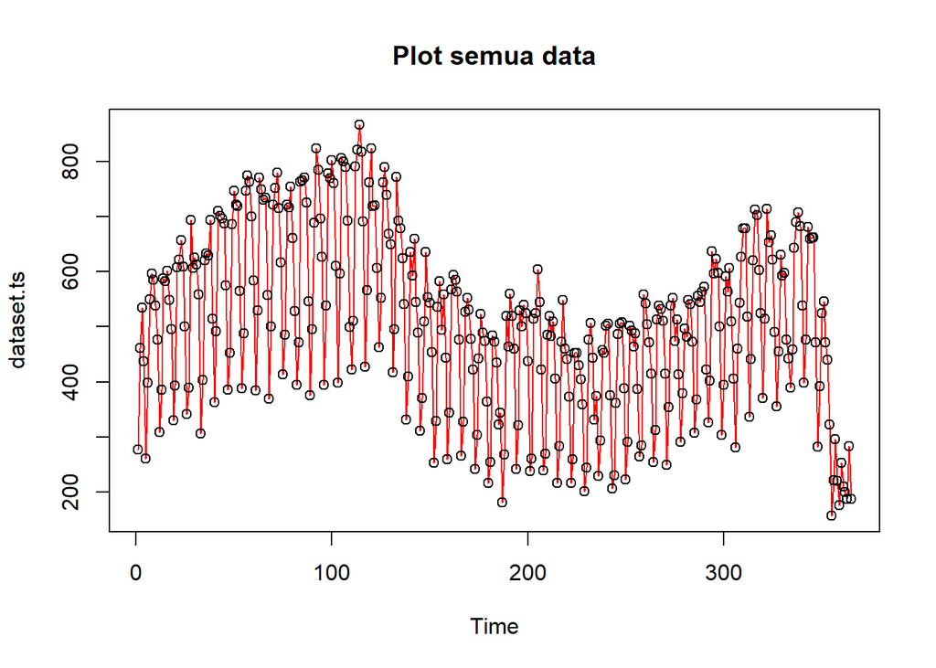

```r
#eksplorasi keseluruhan data
plot(dataset.ts, col="red",main="Plot semua data")
points(dataset.ts)
```

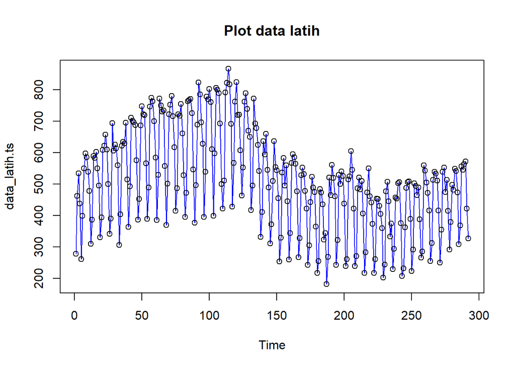

```r
#eksplorasi data latih
plot(data_latih.ts, col="blue",main="Plot data latih")
points(data_latih.ts)
```

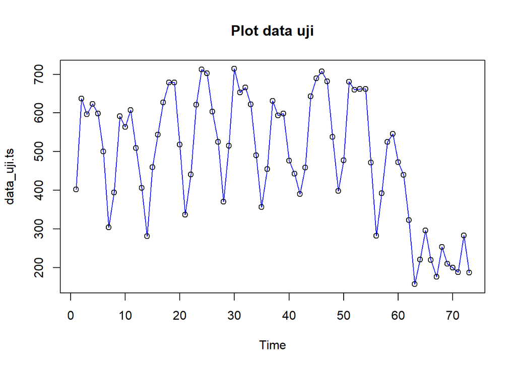

```r
#eksplorasi data uji
plot(data_uji.ts, col="blue",main="Plot data uji")
points(data_uji.ts)
```

### Single Moving Average (SMA)

Ide dasar: data suatu periode dipengaruhi oleh data periode sebelumnya. Metode ini cocok digunakan untuk pola data stasioner atau konstan. Prinsip dasar: data pemulusan pada periode ke-t merupakan rata rata dari m buah data pada periode ke-t hingga periode ke (t-m+1). Data pemulusan pada periode ke-t selanjutnya digunakan sebagai nilai peramalan pada periode ke t+1

Pemulusan menggunakan metode SMA dilakukan dengan fungsi `SMA()`. Dalam hal ini akan dilakukan pemulusan dengan parameter `m=4`.

```r
data.sma<-SMA(data_latih.ts, n=4)
data.sma
```

```
## Time Series:
## Start = 1
## End = 292
## Frequency = 1
##   [1]     NA     NA     NA 427.50 423.50 407.50 411.50 451.50 532.50 567.50
##  [11] 549.25 477.25 427.50 440.00 466.25 539.50 580.25 557.00 494.00 441.75
##  [21] 456.50 488.25 570.00 624.00 597.00 526.75 460.00 481.00 507.50 578.50
##  [31] 634.25 600.75 525.75 470.25 472.25 490.75 571.50 644.25 617.50 550.00
##  [41] 515.75 519.75 566.50 649.75 698.50 664.75 586.00 525.00 524.75 567.75
##  [51] 651.75 718.50 688.25 598.50 540.00 546.75 599.00 692.75 745.75 705.25
##  [61] 608.00 549.50 567.25 608.50 694.75 746.00 692.50 597.50 540.25 537.00
##  [71] 585.75 688.50 742.00 716.00 631.50 558.00 559.50 584.25 669.25 713.00
##  [81] 664.75 584.50 514.00 539.50 599.00 692.75 756.00 701.75 604.25 535.75
##  [91] 526.50 595.75 698.00 748.00 732.75 625.75 564.25 584.75 620.25 722.00
## [101] 777.25 735.25 642.50 591.25 602.75 650.25 748.00 771.75 695.00 600.50
```

[output cut: 19 more lines]

Data pemulusan pada periode ke-t selanjutnya digunakan sebagai nilai peramalan pada periode ke t+1 sehingga hasil peramalan 1 periode kedepan adalah sebagai berikut.

```r
data.ramal<-c(NA,data.sma)
data.ramal #forecast 1 periode ke depan
```

```
##   [1]     NA     NA     NA     NA 427.50 423.50 407.50 411.50 451.50 532.50
##  [11] 567.50 549.25 477.25 427.50 440.00 466.25 539.50 580.25 557.00 494.00
##  [21] 441.75 456.50 488.25 570.00 624.00 597.00 526.75 460.00 481.00 507.50
##  [31] 578.50 634.25 600.75 525.75 470.25 472.25 490.75 571.50 644.25 617.50
##  [41] 550.00 515.75 519.75 566.50 649.75 698.50 664.75 586.00 525.00 524.75
##  [51] 567.75 651.75 718.50 688.25 598.50 540.00 546.75 599.00 692.75 745.75
##  [61] 705.25 608.00 549.50 567.25 608.50 694.75 746.00 692.50 597.50 540.25
##  [71] 537.00 585.75 688.50 742.00 716.00 631.50 558.00 559.50 584.25 669.25
##  [81] 713.00 664.75 584.50 514.00 539.50 599.00 692.75 756.00 701.75 604.25
##  [91] 535.75 526.50 595.75 698.00 748.00 732.75 625.75 564.25 584.75 620.25
## [101] 722.00 777.25 735.25 642.50 591.25 602.75 650.25 748.00 771.75 695.00
## [111] 600.50 531.00 555.75 636.25 747.25 823.75 798.75 700.25 625.25 611.50
## [121] 644.75 717.75 756.25 717.50 627.25 585.50 596.00 641.50 710.50 739.75
## [131] 711.75 618.75 557.75 583.50 594.00 659.25 691.50 633.75 543.50 476.50
## [141] 479.50 492.50 574.50 608.25 571.50 501.00 429.00 420.00 456.75 517.25
## [151] 560.25 546.50 450.75 394.75 393.00 425.00 485.25 542.75 519.75 439.00
## [161] 401.50 403.50 441.00 522.50 577.50 554.75 472.75 408.50 399.25 418.25
## [171] 484.50 522.00 495.75 418.25 361.50 352.50 377.75 439.50 482.00 462.50
## [181] 385.75 327.00 329.50 356.75 411.50 428.75 393.75 320.75 279.00 328.25
## [191] 358.25 453.00 515.75 500.75 445.25 385.50 388.00 398.00 472.50 523.50
## [201] 500.50 435.00 365.25 362.50 384.25 475.75 546.75 523.75 452.50 369.00
## [211] 354.25 378.75 439.75 499.50 479.50 403.50 353.50 344.50 380.25 441.25
## [221] 480.75 455.75 372.50 322.50 325.50 345.25 398.75 434.75 411.25 348.75
## [231] 302.25 320.25 357.25 417.75 439.75 414.25 344.75 307.25 338.50 358.25
## [241] 426.50 479.25 458.75 397.25 329.50 293.75 321.75 396.50 465.75 472.25
## [251] 406.25 352.50 351.00 377.25 437.50 486.75 458.00 401.00 356.25 374.00
## [261] 412.75 472.50 519.25 483.25 411.50 363.50 373.75 404.75 474.00 523.50
## [271] 499.00 426.50 382.00 389.00 423.25 479.50 519.25 488.25 423.00 399.25
## [281] 395.25 412.00 476.25 516.75 510.75 467.50 422.50 426.25 444.25 508.00
## [291] 559.00 525.50 470.75
```

Selanjutnya akan dilakukan peramalan sejumlah data uji yaitu 73 periode. Pada metode SMA, hasil peramalan 73 periode ke depan akan bernilai sama dengan hasil peramalan 1 periode kedepan. Dalam hal ini akan dilakukan pengguabungan data aktual latih/train, data hasil pemulusan dan data hasil ramalan 73 periode kedepan.

```r
data.gab<-cbind(aktual=c(data_latih.ts,rep(NA,73)),pemulusan=c(data.sma,rep(NA,73)),ramalan=c(data.ramal,rep(data.ramal[length(data.ramal)],72)))
data.gab #forecast 24 periode ke depan
```

```
##        aktual pemulusan ramalan
##   [1,]    277        NA      NA
##   [2,]    462        NA      NA
##   [3,]    534        NA      NA
##   [4,]    437    427.50      NA
##   [5,]    261    423.50  427.50
##   [6,]    398    407.50  423.50
##   [7,]    550    411.50  407.50
##   [8,]    597    451.50  411.50
##   [9,]    585    532.50  451.50
##  [10,]    538    567.50  532.50
##  [11,]    477    549.25  567.50
##  [12,]    309    477.25  549.25
##  [13,]    386    427.50  477.25
##  [14,]    588    440.00  427.50
```

[output cut: 351 more lines]

Adapun plot data deret waktu dari hasil peramalan yang dilakukan adalah sebagai berikut.

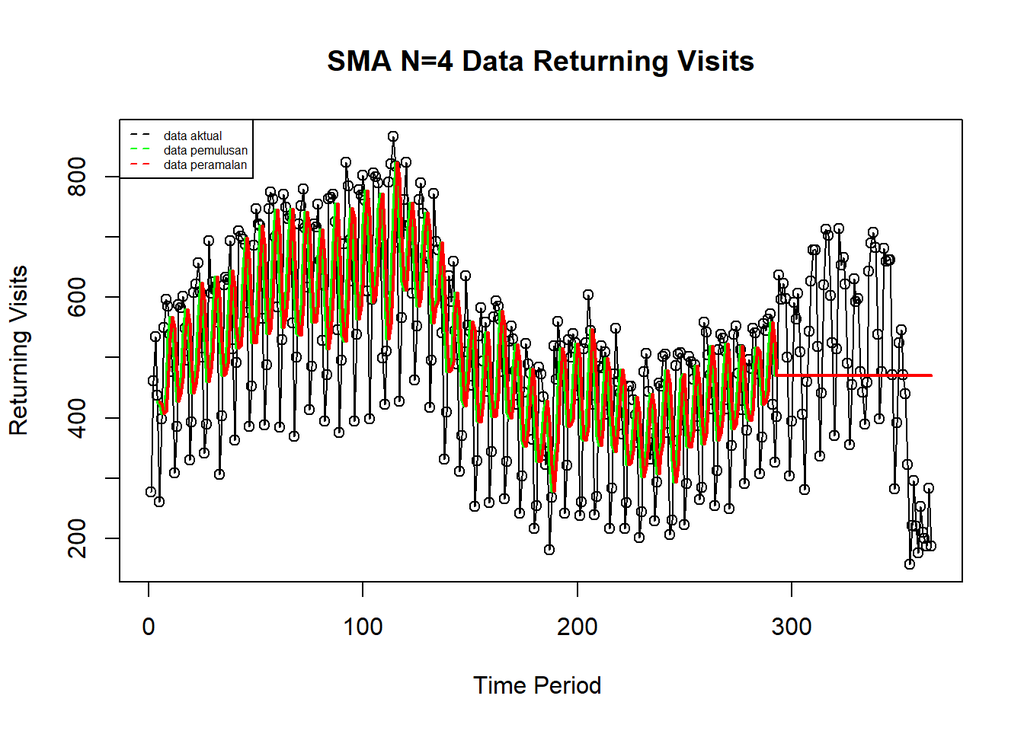

```r
ts.plot(dataset.ts, xlab="Time Period ", ylab="Returning Visits", main= "SMA N=4 Data Returning Visits")
points(dataset.ts)
lines(data.gab[,2],col="green",lwd=2)
lines(data.gab[,3],col="red",lwd=2)
legend("topleft",c("data aktual","data pemulusan","data peramalan"), lty=8, col=c("black","green","red"), cex=0.5)
```

Selanjutnya perhitungan akurasi dilakukan dengan ukuran akurasi *Sum Squares Error* (SSE), *Mean Square Error* (MSE) dan *Mean Absolute Percentage Error* (MAPE). Perhitungan akurasi dilakukan baik pada data latih maupun pada data uji.

```r
#Menghitung nilai keakuratan data latih
error_train.sma = data_latih.ts-data.ramal[1:length(data_latih.ts)]
SSE_train.sma = sum(error_train.sma[5:length(data_latih.ts)]^2)
MSE_train.sma = mean(error_train.sma[5:length(data_latih.ts)]^2)
MAPE_train.sma = mean(abs((error_train.sma[5:length(data_latih.ts)]/data_latih.ts[5:length(data_latih.ts)])*100))

akurasi_train.sma <- matrix(c(SSE_train.sma, MSE_train.sma, MAPE_train.sma))
row.names(akurasi_train.sma)<- c("SSE", "MSE", "MAPE")
colnames(akurasi_train.sma) <- c("Akurasi m = 4")
akurasi_train.sma
```

```
##      Akurasi m = 4
## SSE   7.515205e+06
## MSE   2.609446e+04
## MAPE  3.279864e+01
```

```r
#Menghitung nilai keakuratan data uji
error_test.sma = data_uji.ts-data.gab[293:365,3]
SSE_test.sma = sum(error_test.sma^2)
MSE_test.sma = mean(error_test.sma^2)
MAPE_test.sma = mean(abs((error_test.sma/data_uji.ts*100)))

akurasi_test.sma <- matrix(c(SSE_test.sma, MSE_test.sma, MAPE_test.sma))
row.names(akurasi_test.sma)<- c("SSE", "MSE", "MAPE")
colnames(akurasi_test.sma) <- c("Akurasi m = 4")
akurasi_test.sma
```

```
##      Akurasi m = 4
## SSE   1.881647e+06
## MSE   2.577599e+04
## MAPE  3.718348e+01
```

### Double Moving Average (DMA)

Metode pemulusan Double Moving Average (DMA) pada dasarnya mirip dengan SMA. Namun demikian, metode ini lebih cocok digunakan untuk pola data trend. Proses pemulusan dengan rata rata dalam metode ini dilakukan sebanyak 2 kali.

```r
dma <- SMA(data.sma, n = 4)
At <- 2*data.sma - dma
Bt <- 2/(4-1)*(data.sma - dma)
data.dma<- At+Bt
data.ramal2<- c(NA, data.dma)

t = 1:73
f = c()

for (i in t) {
  f[i] = At[length(At)] + Bt[length(Bt)]*(i)
}

data.gab2 <- cbind(aktual = c(data_latih.ts,rep(NA,73)), pemulusan1 = c(data.sma,rep(NA,73)),pemulusan2 = c(data.dma, rep(NA,73)),At = c(At, rep(NA,73)), Bt = c(Bt,rep(NA,73)),ramalan = c(data.ramal2, f[-1]))
data.gab2
```

```
##        aktual pemulusan1 pemulusan2       At          Bt      ramalan
##   [1,]    277         NA         NA       NA          NA           NA
##   [2,]    462         NA         NA       NA          NA           NA
##   [3,]    534         NA         NA       NA          NA           NA
##   [4,]    437     427.50         NA       NA          NA           NA
##   [5,]    261     423.50         NA       NA          NA           NA
##   [6,]    398     407.50         NA       NA          NA           NA
##   [7,]    550     411.50   401.5000 405.5000  -4.0000000           NA
##   [8,]    597     451.50   498.1667 479.5000  18.6666667   401.500000
##   [9,]    585     532.50   668.7500 614.2500  54.5000000   498.166667
##  [10,]    538     567.50   695.4167 644.2500  51.1666667   668.750000
##  [11,]    477     549.25   589.3542 573.3125  16.0416667   695.416667
##  [12,]    309     477.25   386.6250 422.8750 -36.2500000   589.354167
##  [13,]    386     427.50   297.7083 349.6250 -51.9166667   386.625000
##  [14,]    588     440.00   384.1667 406.5000 -22.3333333   297.708333
```

[output cut: 351 more lines]

Hasil pemulusan menggunakan metode DMA divisualisasikan sebagai berikut

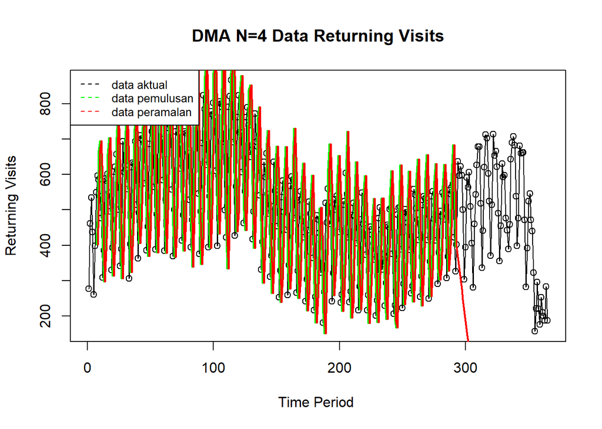

```r
ts.plot(dataset.ts, xlab="Time Period ", ylab="Returning Visits", main= "DMA N=4 Data Returning Visits")
points(dataset.ts)
lines(data.gab2[,3],col="green",lwd=2)
lines(data.gab2[,6],col="red",lwd=2)
legend("topleft",c("data aktual","data pemulusan","data peramalan"), lty=8, col=c("black","green","red"), cex=0.8)
```

Selanjutnya perhitungan akurasi dilakukan baik pada data latih maupun data uji. Perhitungan akurasi dilakukan dengan ukuran akurasi SSE, MSE dan MAPE.

```r
#Menghitung nilai keakuratan data latih
error_train.dma = data_latih.ts-data.ramal2[1:length(data_latih.ts)]
SSE_train.dma = sum(error_train.dma[8:length(data_latih.ts)]^2)
MSE_train.dma = mean(error_train.dma[8:length(data_latih.ts)]^2)
MAPE_train.dma = mean(abs((error_train.dma[8:length(data_latih.ts)]/data_latih.ts[8:length(data_latih.ts)])*100))

akurasi_train.dma <- matrix(c(SSE_train.dma, MSE_train.dma, MAPE_train.dma))
row.names(akurasi_train.dma)<- c("SSE", "MSE", "MAPE")
colnames(akurasi_train.dma) <- c("Akurasi m = 4")
akurasi_train.dma
```

```
##      Akurasi m = 4
## SSE   1.433807e+07
## MSE   5.030901e+04
## MAPE  4.198977e+01
```

```r
#Menghitung nilai keakuratan data uji
error_test.dma = data_uji.ts-data.gab2[293:365,6]
SSE_test.dma = sum(error_test.dma^2)
MSE_test.dma = mean(error_test.dma^2)
MAPE_test.dma = mean(abs((error_test.dma/data_uji.ts*100)))

akurasi_test.dma <- matrix(c(SSE_test.dma, MSE_test.dma, MAPE_test.dma))
row.names(akurasi_test.dma)<- c("SSE", "MSE", "MAPE")
colnames(akurasi_test.dma) <- c("Akurasi m = 4")
akurasi_test.dma
```

```
##      Akurasi m = 4
## SSE   1.247089e+08
## MSE   1.708342e+06
## MAPE  3.048154e+02
```

## Single Exponential Smoothing & Double Exponential Smoothing

Metode *Exponential Smoothing* adalah metode pemulusan dengan melakukan pembobotan menurun secara eksponensial. Nilai yang lebih baru diberi bobot yang lebih besar dari nilai terdahulu. Terdapat satu atau lebih parameter pemulusan yang ditentukan secara eksplisit, dan hasil pemilihan parameter tersebut akan menentukan bobot yang akan diberikan pada nilai pengamatan. Ada dua macam model, yaitu model tunggal dan ganda.

### Pembagian Data

Pembagian data latih dan data uji dilakukan dengan perbandingan 80% data latih dan 20% data uji.

```r
#membagi training dan testing
training<-dataset[1:292,]
testing<-dataset[293:365,]
train.ts <- ts(training$Returning.Visits)
test.ts <- ts(testing$Returning.Visits)
```

### Eksplorasi

Eksplorasi dilakukan dengan membuat plot data deret waktu untuk keseluruhan data, data latih, dan data uji.

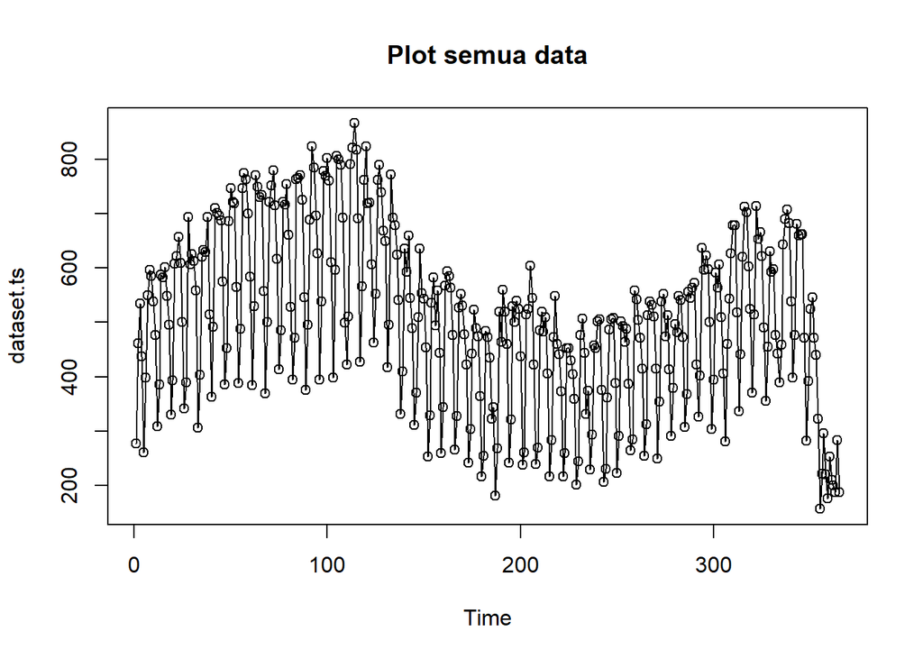

```r
#eksplorasi data
plot(dataset.ts, col="black",main="Plot semua data")
points(dataset.ts)
```

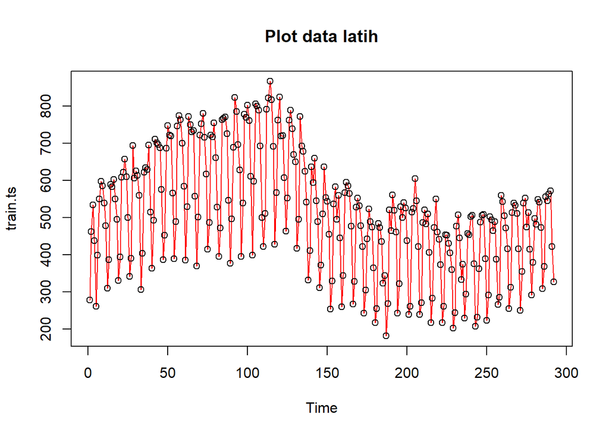

```r
plot(train.ts, col="red",main="Plot data latih")
points(train.ts)
```

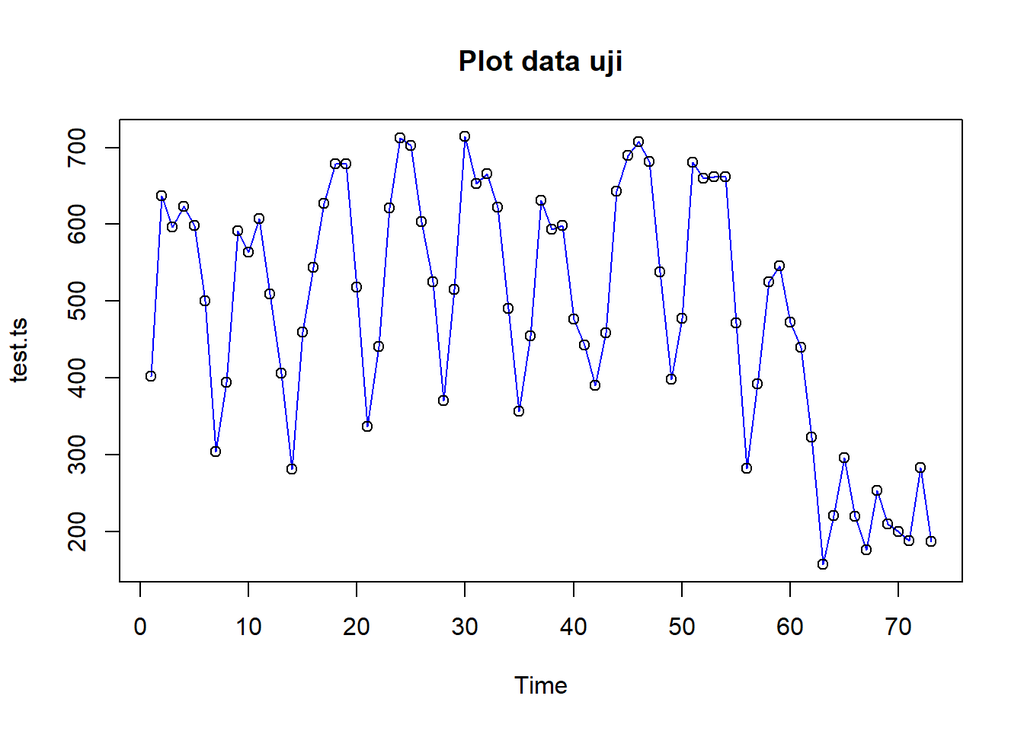

```r
plot(test.ts, col="blue",main="Plot data uji")
points(test.ts)
```

### SES

Single Exponential Smoothing merupakan metode pemulusan yang tepat digunakan untuk data dengan pola stasioner atau konstan.

Nilai pemulusan pada periode ke-t didapat dari persamaan:

$$\tilde{y}_T=\lambda y_t+(1-\lambda)\tilde{y}_{T-1}$$

Nilai parameter $\lambda$ adalah nilai antara 0 dan 1.

Nilai pemulusan periode ke-t bertindak sebagai nilai ramalan pada periode ke-$(T+\tau)$.

$$\tilde{y}_{T+\tau}(T)=\tilde{y}_T$$

Pemulusan dengan metode SES dapat dilakukan dengan dua fungsi dari *packages* berbeda, yaitu (1) fungsi `ses()` dari *packages* `forecast` dan (2) fungsi `HoltWinters` dari *packages* `stats` .

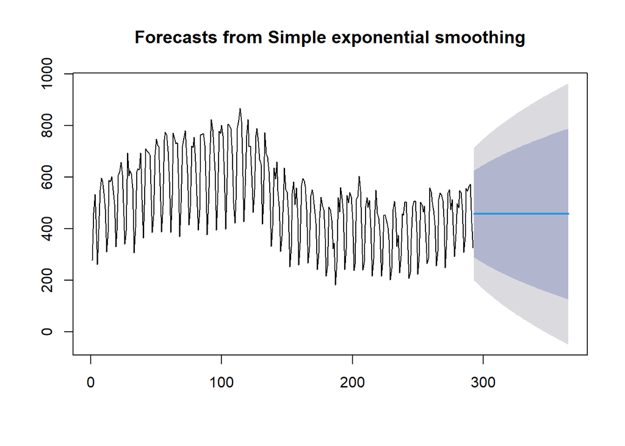

```r
#Cara 1 (fungsi ses)
ses.1 <- ses(train.ts, h = 73, alpha = 0.2)
plot(ses.1)
```

```r
ses.1
```

```
##     Point Forecast    Lo 80    Hi 80       Lo 95    Hi 95
## 293       456.9916 288.9683 625.0149 200.0221582 713.9611
## 294       456.9916 285.6408 628.3424 194.9331602 719.0501
## 295       456.9916 282.3767 631.6065 189.9411221 724.0421
## 296       456.9916 279.1725 634.8107 185.0407044 728.9425
## 297       456.9916 276.0250 637.9582 180.2270404 733.7562
## 298       456.9916 272.9313 641.0519 175.4956794 738.4875
## 299       456.9916 269.8888 644.0944 170.8425389 743.1407
## 300       456.9916 266.8950 647.0883 166.2638630 747.7194
## 301       456.9916 263.9475 650.0357 161.7561873 752.2270
## 302       456.9916 261.0445 652.9388 157.3163078 756.6669
## 303       456.9916 258.1838 655.7994 152.9412544 761.0420
## 304       456.9916 255.3637 658.6196 148.6282680 765.3549
## 305       456.9916 252.5825 661.4008 144.3747796 769.6084
## 306       456.9916 249.8386 664.1446 140.1783928 773.8048
```

[output cut: 59 more lines]

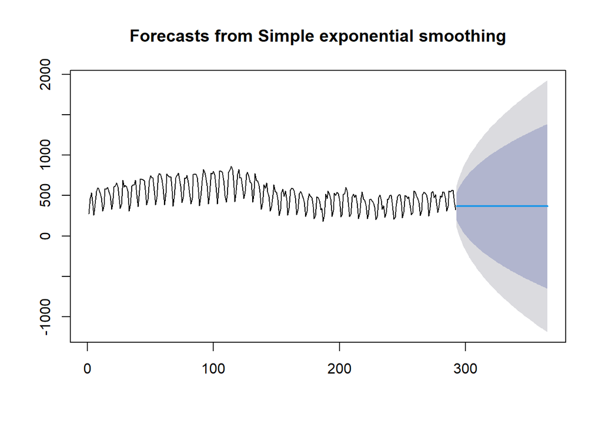

```r
ses.2<- ses(train.ts, h = 73, alpha = 0.7)
plot(ses.2)
```

```r
ses.2
```

```
##     Point Forecast      Lo 80     Hi 80        Lo 95     Hi 95
## 293       367.7998  198.51307  537.0866   108.898071  626.7016
## 294       367.7998  161.15900  574.4407    51.769958  683.8297
## 295       367.7998  129.59224  606.0074     3.492763  732.1069
## 296       367.7998  101.74480  633.8549   -39.096223  774.6959
## 297       367.7998   76.54787  659.0518   -77.631598  813.2313
## 298       367.7998   53.36363  682.2360  -113.088843  848.6885
## 299       367.7998   31.77520  703.8245  -146.105488  881.7051
## 300       367.7998   11.49242  724.1072  -177.125334  912.7250
## 301       367.7998   -7.69637  743.2960  -206.472051  942.0717
## 302       367.7998  -25.95113  761.5508  -234.390300  969.9900
## 303       367.7998  -43.39628  778.9959  -261.070357  996.6700
## 304       367.7998  -60.13085  795.7305  -286.663669 1022.2633
## 305       367.7998  -76.23518  811.8348  -311.293117 1046.8928
## 306       367.7998  -91.77553  827.3752  -335.060035 1070.6597
```

[output cut: 59 more lines]

Untuk mendapatkan gambar hasil pemulusan pada data latih dengan fungsi `ses()` , perlu digunakan fungsi `autoplot()` dan `autolayer()` dari *library packages* `ggplot2` .

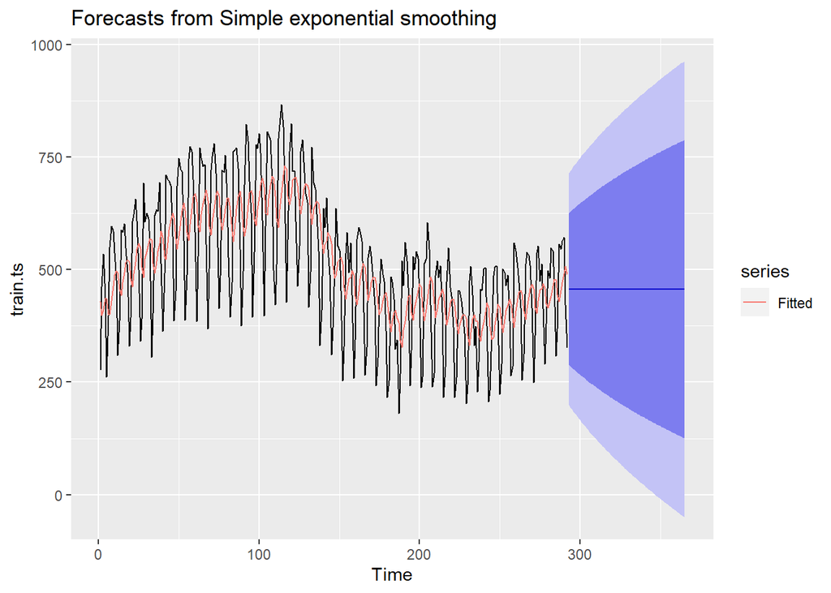

```r
autoplot(ses.1) +
  autolayer(fitted(ses.1), series="Fitted")
```

Pada fungsi `ses()` , terdapat beberapa argumen yang umum digunakan, yaitu nilia `y` , `gamma` , `beta` , `alpha` , dan `h` .

Nilai `y` adalah nilai data deret waktu, `gamma` adalah parameter pemulusan untuk komponen musiman, `beta` adalah parameter pemulusan untuk tren, dan `alpha` adalah parameter pemulusan untuk stasioner, serta `h` adalah banyaknya periode yang akan diramalkan.

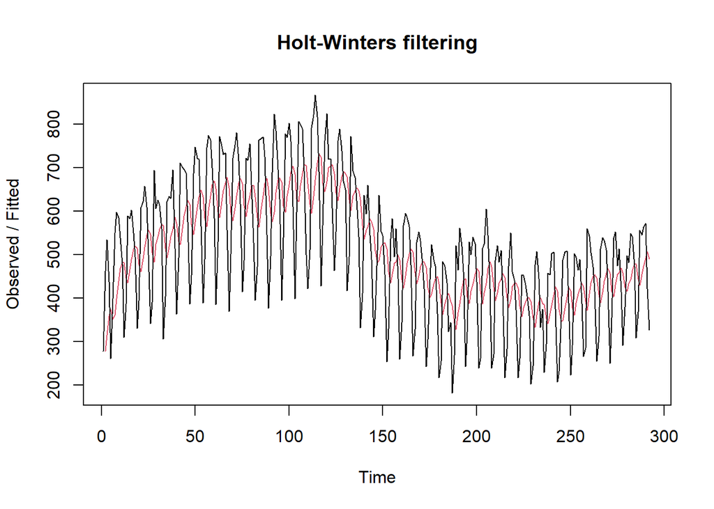

```r
#Cara 2 (fungsi Holtwinter)
ses1<- HoltWinters(train.ts, gamma = FALSE, beta = FALSE, alpha = 0.2)
plot(ses1)
```

```r
#ramalan
ramalan1<- forecast(ses1, h=73)
ramalan1
```

```
##     Point Forecast    Lo 80    Hi 80       Lo 95    Hi 95
## 293       456.9916 287.9398 626.0434 198.4492059 715.5340
## 294       456.9916 284.5919 629.3913 193.3290573 720.6542
## 295       456.9916 281.3078 632.6754 188.3064622 725.6768
## 296       456.9916 278.0840 635.8992 183.3760483 730.6072
## 297       456.9916 274.9173 639.0660 178.5329190 735.4503
## 298       456.9916 271.8047 642.1786 173.7725966 740.2106
## 299       456.9916 268.7435 645.2397 169.0909734 744.8922
## 300       456.9916 265.7313 648.2519 164.4842707 749.4989
## 301       456.9916 262.7659 651.2173 159.9490028 754.0342
## 302       456.9916 259.8450 654.1382 155.4819460 758.5013
## 303       456.9916 256.9668 657.0164 151.0801123 762.9031
## 304       456.9916 254.1295 659.8538 146.7407254 767.2425
## 305       456.9916 251.3312 662.6520 142.4612007 771.5220
## 306       456.9916 248.5706 665.4127 138.2391271 775.7441
```

[output cut: 59 more lines]

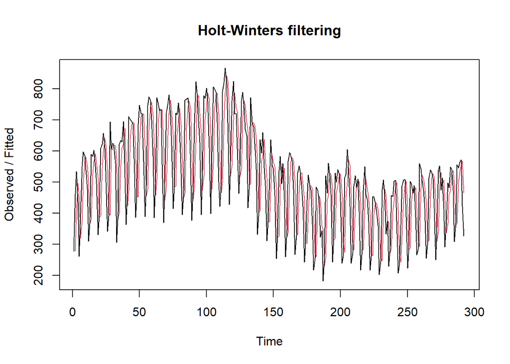

```r
ses2<- HoltWinters(train.ts, gamma = FALSE, beta = FALSE, alpha = 0.7)
plot(ses2)
```

```r
#ramalan
ramalan2<- forecast(ses2, h=73)
ramalan2
```

```
##     Point Forecast       Lo 80     Hi 80        Lo 95     Hi 95
## 293       367.7998  198.451385  537.1483   108.803733  626.7959
## 294       367.7998  161.083709  574.5160    51.654804  683.9449
## 295       367.7998  129.505445  606.0942     3.360017  732.2396
## 296       367.7998  101.647857  633.9518   -39.244487  774.8441
## 297       367.7998   76.441748  659.1579   -77.793904  813.3936
## 298       367.7998   53.249054  682.3506  -113.264069  848.8637
## 299       367.7998   31.652764  703.9469  -146.292744  881.8924
## 300       367.7998   11.362586  724.2371  -177.323894  912.9236
## 301       367.7998   -7.833193  743.4329  -206.681304  942.2810
## 302       367.7998  -26.094606  761.6943  -234.609726  970.2094
## 303       367.7998  -43.546114  779.1458  -261.299504  996.8992
## 304       367.7998  -60.286779  795.8864  -286.902142 1022.5018
## 305       367.7998  -76.396978  811.9966  -311.540564 1047.1402
## 306       367.7998  -91.942993  827.5427  -335.316142 1070.9158
```

[output cut: 59 more lines]

Fungsi `HoltWinters` memiliki argumen yang sama dengan fungsi `ses()` . Argumen-argumen kedua fungsi dapat dilihat lebih lanjut dengan `?ses()` atau `?HoltWinters` .

Nilai parameter $\alpha$ dari kedua fungsi dapat dioptimalkan menyesuaikan dari *error*-nya paling minimumnya. Caranya adalah dengan membuat parameter $\alpha =$ `NULL` .

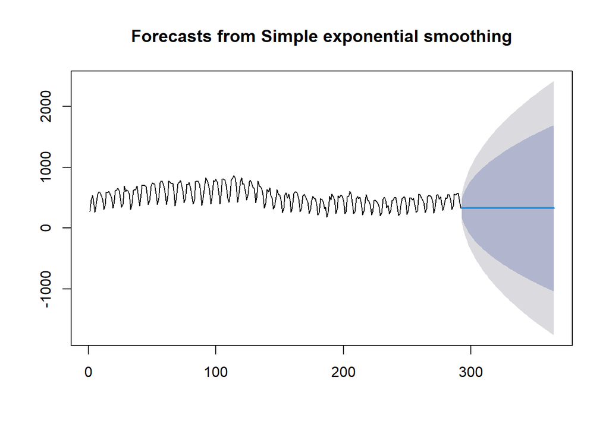

```r
#SES
ses.opt <- ses(train.ts, h = 73, alpha = NULL)
plot(ses.opt)
```

```r
ses.opt
```

```
##     Point Forecast        Lo 80     Hi 80       Lo 95     Hi 95
## 293       326.0096   166.295544  485.7237    81.74803  570.2712
## 294       326.0096   100.151109  551.8681   -19.41115  671.4304
## 295       326.0096    49.395182  602.6240   -97.03565  749.0549
## 296       326.0096     6.605445  645.4138  -162.47690  814.4961
## 297       326.0096   -31.093316  683.1125  -220.13218  872.1514
## 298       326.0096   -65.175741  717.1949  -272.25675  924.2760
## 299       326.0096   -96.517854  748.5371  -320.19038  972.2096
## 300       326.0096  -125.690442  777.7096  -364.80600 1016.8252
## 301       326.0096  -153.089979  805.1092  -406.70998 1058.7292
## 302       326.0096  -179.005137  831.0243  -446.34379 1098.3630
## 303       326.0096  -203.653843  855.6730  -484.04073 1136.0599
## 304       326.0096  -227.205405  879.2246  -520.05974 1172.0789
## 305       326.0096  -249.794464  901.8137  -554.60672 1206.6259
## 306       326.0096  -271.530188  923.5494  -587.84865 1239.8679
```

[output cut: 59 more lines]

```r
#Lamda Optimum Holt Winter
sesopt<- HoltWinters(train.ts, gamma = FALSE, beta = FALSE,alpha = NULL)
sesopt
```

```
## Holt-Winters exponential smoothing without trend and without seasonal component.
##
## Call:
## HoltWinters(x = train.ts, alpha = NULL, beta = FALSE, gamma = FALSE)
##
## Smoothing parameters:
##  alpha: 0.9999339
##  beta : FALSE
##  gamma: FALSE
##
## Coefficients:
##       [,1]
## a 326.0063
```

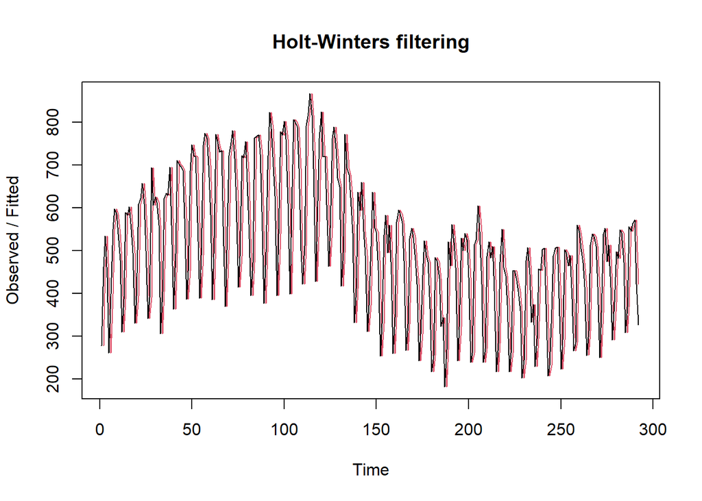

```r
plot(sesopt)
```

```r
#ramalan
ramalanopt<- forecast(sesopt, h=73)
ramalanopt
```

```
##     Point Forecast        Lo 80     Hi 80       Lo 95     Hi 95
## 293       326.0063   166.901414  485.1113    82.67635  569.3363
## 294       326.0063   101.005430  551.0073   -18.10286  670.1156
## 295       326.0063    50.440664  601.5720   -95.43500  747.4477
## 296       326.0063     7.812258  644.2004  -160.62952  812.6422
## 297       326.0063   -29.744284  681.7570  -218.06729  870.0800
## 298       326.0063   -63.698085  715.7108  -269.99515  922.0078
## 299       326.0063   -94.921886  746.9346  -317.74783  969.7605
## 300       326.0063  -123.984330  775.9970  -362.19501 1014.2077
## 301       326.0063  -151.280404  803.2931  -403.94075 1055.9534
## 302       326.0063  -177.097693  829.1104  -443.42488 1095.4376
## 303       326.0063  -201.653305  853.6660  -480.97945 1132.9921
## 304       326.0063  -225.115909  877.1286  -516.86241 1168.8751
## 305       326.0063  -247.619641  899.6323  -551.27890 1203.2916
## 306       326.0063  -269.273257  921.2860  -584.39524 1236.4079
```

[output cut: 59 more lines]

Setelah dilakukan peramalan, akan dilakukan perhitungan keakuratan hasil peramalan. Perhitungan akurasi ini dilakukan baik pada data latih dan data uji.

#### Akurasi Data Latih

Perhitungan akurasi data dapat dilakukan dengan cara langsung maupun manual. Secara langsung, nilai akurasi dapat diambil dari objek yang tersimpan pada hasil SES, yaitu *sum of squared errors* (SSE). Nilai akurasi lain dapat dihitung pula dari nilai SSE tersebut.

```r
#Keakuratan Metode
#Pada data training
SSE1<-ses1$SSE
MSE1<-ses1$SSE/length(train.ts)
RMSE1<-sqrt(MSE1)

akurasi1 <- matrix(c(SSE1,MSE1,RMSE1))
row.names(akurasi1)<- c("SSE", "MSE", "RMSE")
colnames(akurasi1) <- c("Akurasi lamda=0.2")
akurasi1
```

```
##      Akurasi lamda=0.2
## SSE       5048993.9150
## MSE         17291.0751
## RMSE          131.4955
```

```r
SSE2<-ses2$SSE
MSE2<-ses2$SSE/length(train.ts)
RMSE2<-sqrt(MSE2)

akurasi2 <- matrix(c(SSE2,MSE2,RMSE2))
row.names(akurasi2)<- c("SSE", "MSE", "RMSE")
colnames(akurasi2) <- c("Akurasi lamda=0.7")
akurasi2
```

```
##      Akurasi lamda=0.7
## SSE       5063994.3734
## MSE         17342.4465
## RMSE          131.6907
```

```r
#Cara Manual
fitted1<-ramalan1$fitted
sisaan1<-ramalan1$residuals
head(sisaan1)
```

```
## Time Series:
## Start = 1
## End = 6
## Frequency = 1
## [1]      NA  185.00  220.00   79.00 -112.80   46.76
```

```r
resid1<-training$Returning.Visits-ramalan1$fitted
head(resid1)
```

```
## Time Series:
## Start = 1
## End = 6
## Frequency = 1
## [1]      NA  185.00  220.00   79.00 -112.80   46.76
```

```r
#Cara Manual
SSE.1=sum(sisaan1[2:length(train.ts)]^2)
SSE.1
```

```
## [1] 5048994
```

```r
MSE.1 = SSE.1/length(train.ts)
MSE.1
```

```
## [1] 17291.08
```

```r
MAPE.1 = sum(abs(sisaan1[2:length(train.ts)]/train.ts[2:length(train.ts)])*
               100)/length(train.ts)
MAPE.1
```

```
## [1] 26.47922
```

```r
akurasi.1 <- matrix(c(SSE.1,MSE.1,MAPE.1))
row.names(akurasi.1)<- c("SSE", "MSE", "MAPE")
colnames(akurasi.1) <- c("Akurasi lamda=0.2")
akurasi.1
```

```
##      Akurasi lamda=0.2
## SSE       5.048994e+06
## MSE       1.729108e+04
## MAPE      2.647922e+01
```

```r
fitted2<-ramalan2$fitted
sisaan2<-ramalan2$residuals
head(sisaan2)
```

```
## Time Series:
## Start = 1
## End = 6
## Frequency = 1
## [1]        NA  185.0000  127.5000  -58.7500 -193.6250   78.9125
```

```r
resid2<-training$Returning.Visits-ramalan2$fitted
head(resid2)
```

```
## Time Series:
## Start = 1
## End = 6
## Frequency = 1
## [1]        NA  185.0000  127.5000  -58.7500 -193.6250   78.9125
```

```r
SSE.2=sum(sisaan2[2:length(train.ts)]^2)
SSE.2
```

```
## [1] 5063994
```

```r
MSE.2 = SSE.2/length(train.ts)
MSE.2
```

```
## [1] 17342.45
```

```r
MAPE.2 = sum(abs(sisaan2[2:length(train.ts)]/train.ts[2:length(train.ts)])*
               100)/length(train.ts)
MAPE.2
```

```
## [1] 23.35621
```

```r
akurasi.2 <- matrix(c(SSE.2,MSE.2,MAPE.2))
row.names(akurasi.2)<- c("SSE", "MSE", "MAPE")
colnames(akurasi.2) <- c("Akurasi lamda=0.7")
akurasi.2
```

```
##      Akurasi lamda=0.7
## SSE       5.063994e+06
## MSE       1.734245e+04
## MAPE      2.335621e+01
```

#### Akurasi Data Uji

Akurasi data uji dapat dihitung dengan cara yang hampir sama dengan perhitungan akurasi data latih.

```r
selisih1<-ramalan1$mean-testing$Returning.Visits
SSEtesting1<-sum(selisih1^2)
MSEtesting1<-SSEtesting1/length(testing)

selisih2<-ramalan2$mean-testing$Returning.Visits
SSEtesting2<-sum(selisih2^2)
MSEtesting2<-SSEtesting2/length(testing)

selisihopt<-ramalanopt$mean-testing$Returning.Visits
SSEtestingopt<-sum(selisihopt^2)
MSEtestingopt<-SSEtestingopt/length(testing)

akurasitesting1 <- matrix(c(SSEtesting1,SSEtesting2,SSEtestingopt))
row.names(akurasitesting1)<- c("SSE1", "SSE2", "SSEopt")
akurasitesting1
```

```
##           [,1]
## SSE1   1927639
## SSE2   2896104
## SSEopt 3749533
```

```r
akurasitesting2 <- matrix(c(MSEtesting1,MSEtesting2,MSEtestingopt))
row.names(akurasitesting2)<- c("MSE1", "MSE2", "MSEopt")
akurasitesting2
```

```
##             [,1]
## MSE1    963819.7
## MSE2   1448051.9
## MSEopt 1874766.5
```

Selain dengan cara di atas, perhitungan nilai akurasi dapat menggunakan fungsi `accuracy()` dari *package* `forecast` . Penggunaannya yaitu dengan menuliskan `accuracy(hasil ramalan, kondisi aktual)` . Contohnya adalah sebagai berikut.

```r
#cara lain
accuracy(ramalanopt,testing$Returning.Visits)
```

```
##                       ME     RMSE       MAE       MPE     MAPE     MASE
## Training set   0.1684178 123.9369  98.63591 -4.151677 22.76446 1.000002
## Test set     160.7607764 226.6351 196.62640 21.556912 39.32528 1.993460
##                   ACF1
## Training set 0.2047367
## Test set            NA
```

### DES

Metode pemulusan *Double Exponential Smoothing* (DES) digunakan untuk data yang memiliki pola tren. Metode DES adalah metode semacam SES, hanya saja dilakukan dua kali, yaitu pertama untuk tahapan ‘level’ dan kedua untuk tahapan ‘tren’. Pemulusan menggunakan metode ini akan menghasilkan peramalan tidak konstan untuk periode berikutnya.

Pemulusan dengan metode DES kali ini akan menggunakan fungsi `HoltWinters()` . Jika sebelumnya nilai argumen `beta` dibuat `FALSE` , kali ini argumen tersebut akan diinisialisasi bersamaan dengan nilai `alpha` .

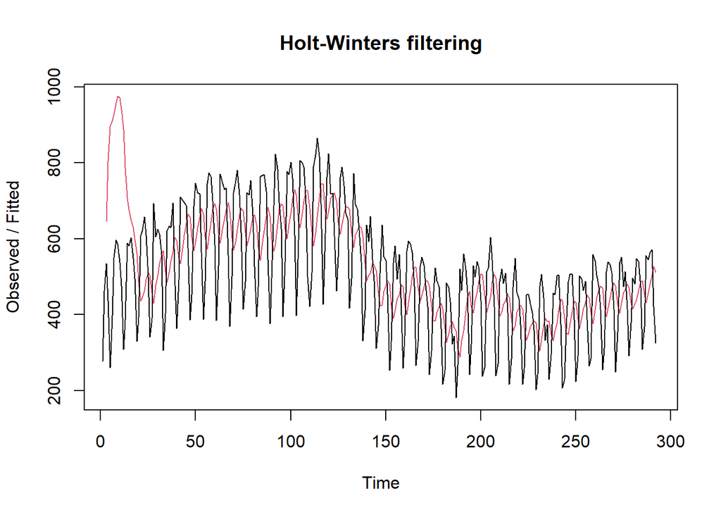

```r
#Lamda=0.2 dan gamma=0.2
des.1<- HoltWinters(train.ts, gamma = FALSE, beta = 0.2, alpha = 0.2)
plot(des.1)
```

```r
#ramalan
ramalandes1<- forecast(des.1, h=73)
ramalandes1
```

```
##     Point Forecast        Lo 80     Hi 80        Lo 95     Hi 95
## 293       473.6872   268.571249  678.8031   159.989442  787.3849
## 294       472.3290   261.388468  683.2696   149.723285  794.9348
## 295       470.9709   252.351566  689.5902   136.621493  805.3203
## 296       469.6127   241.352727  697.8727   120.519178  818.7063
## 297       468.2546   228.347877  708.1613   101.348933  835.1603
## 298       466.8965   213.347958  720.4449    79.127493  854.6654
## 299       465.5383   196.406219  734.6704    53.936296  877.1403
## 300       464.1802   177.604531  750.7558    25.900553  902.4598
## 301       462.8220   157.041042  768.6030    -4.829633  930.4737
## 302       461.4639   134.820411  788.1074   -38.094198  961.0220
## 303       460.1057   111.046903  809.1646   -73.733683  993.9452
## 304       458.7476    85.820013  831.6752  -111.595925 1029.0911
## 305       457.3895    59.232043  855.5469  -151.539759 1066.3187
## 306       456.0313    31.367059  880.6956  -193.436618 1105.4992
```

[output cut: 59 more lines]

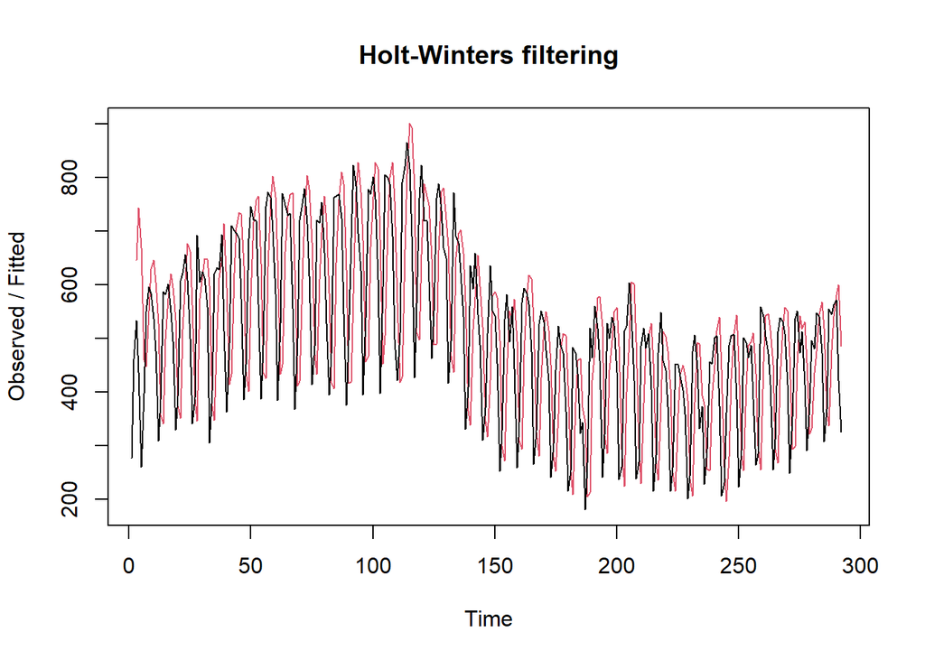

```r
#Lamda=0.6 dan gamma=0.3
des.2<- HoltWinters(train.ts, gamma = FALSE, beta = 0.3, alpha = 0.6)
plot(des.2)
```

```r
#ramalan
ramalandes2<- forecast(des.2, h=73)
ramalandes2
```

```
##     Point Forecast        Lo 80      Hi 80        Lo 95      Hi 95
## 293     353.972171    149.20170   558.7426     40.80276   667.1416
## 294     317.914665     58.21920   577.6101    -79.25527   715.0846
## 295     281.857159    -43.85022   607.5645   -216.26929   779.9836
## 296     245.799652   -154.92314   646.5224   -367.05297   858.6523
## 297     209.742146   -273.62028   693.1046   -529.49689   948.9812
## 298     173.684640   -399.01411   746.3834   -702.18252  1049.5518
## 299     137.627134   -530.45203   805.7063   -884.11177  1159.3660
## 300     101.569628   -667.45187   870.5911  -1074.54727  1277.6865
## 301      65.512122   -809.64152   940.6658  -1272.91987  1403.9441
## 302      29.454616   -956.72304  1015.6323  -1478.77396  1537.6832
## 303      -6.602891  -1108.45071  1095.2449  -1691.73372  1678.5279
## 304     -42.660397  -1264.61693  1179.2961  -1911.48165  1826.1609
## 305     -78.717903  -1425.04289  1267.6071  -2137.74428  1980.3085
## 306    -114.775409  -1589.57210  1360.0213  -2370.28231  2140.7315
```

[output cut: 59 more lines]

Selanjutnya jika ingin membandingkan plot data latih dan data uji adalah sebagai berikut.

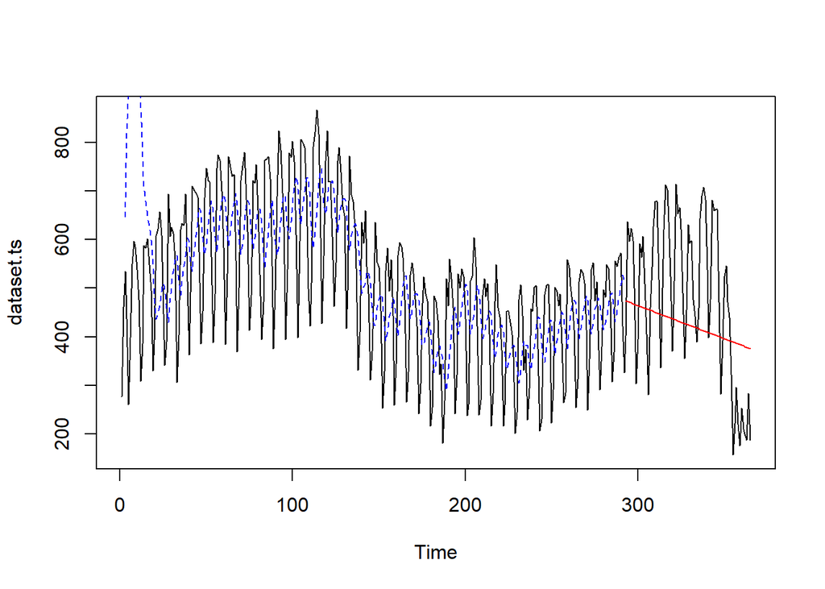

```r
#Visually evaluate the prediction
plot(dataset.ts)
lines(des.1$fitted[,1], lty=2, col="blue")
lines(ramalandes1$mean, col="red")
```

Untuk mendapatkan nilai parameter optimum dari DES, argumen `alpha` dan `beta` dapat dibuat `NULL` seperti berikut.

```r
#Lamda dan gamma optimum
des.opt<- HoltWinters(train.ts, gamma = FALSE)
des.opt
```

```
## Holt-Winters exponential smoothing with trend and without seasonal component.
##
## Call:
## HoltWinters(x = train.ts, gamma = FALSE)
##
## Smoothing parameters:
##  alpha: 1
##  beta : 0.06152207
##  gamma: FALSE
##
## Coefficients:
##         [,1]
## a 326.000000
## b  -8.208134
```

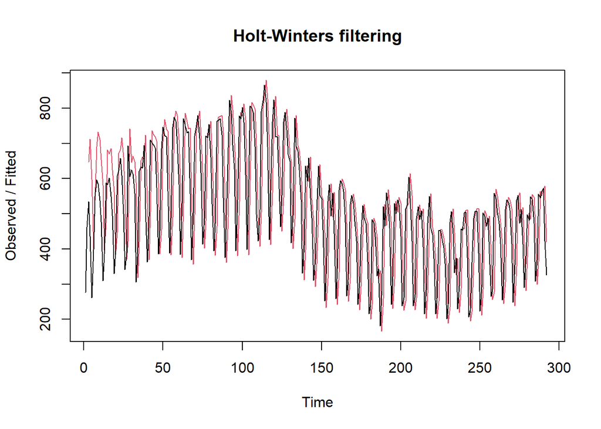

```r
plot(des.opt)
```

```r
#ramalan
ramalandesopt<- forecast(des.opt, h=73)
ramalandesopt
```

```
##     Point Forecast       Lo 80     Hi 80       Lo 95     Hi 95
## 293     317.791866   150.07197  485.5118    61.28642  574.2973
## 294     309.583732    64.98687  554.1806   -64.49489  683.6623
## 295     301.375598    -7.34098  610.0922  -170.76566  773.5169
## 296     293.167464   -73.95351  660.2884  -268.29561  854.6305
## 297     284.959330  -137.48145  707.4001  -361.10810  931.0268
## 298     276.751196  -199.22579  752.7282  -451.19278 1004.6952
## 299     268.543062  -259.93056  797.0167  -539.68760 1076.7737
## 300     260.334928  -320.06149  840.7313  -627.30479 1147.9746
## 301     252.126794  -379.92852  884.1821  -714.51839 1218.7720
## 302     243.918660  -439.74725  927.5846  -801.65812 1289.4954
## 303     235.710526  -499.67264  971.0937  -888.96097 1360.3820
## 304     227.502392  -559.81892 1014.8237  -976.60165 1431.6064
## 305     219.294258  -620.27191 1058.8604 -1064.71140 1503.2999
## 306     211.086124  -681.09707 1103.2693 -1153.39033 1575.5626
```

[output cut: 59 more lines]

Selanjutnya akan dilakukan perhitungan akurasi pada data latih maupun data uji dengan ukuran akurasi SSE, MSE dan MAPE.

#### Akurasi Data Latih

```r
#Akurasi Data Training
ssedes.train1<-des.1$SSE
msedes.train1<-ssedes.train1/length(train.ts)
sisaandes1<-ramalandes1$residuals
head(sisaandes1)
```

```
## Time Series:
## Start = 1
## End = 6
## Frequency = 1
## [1]        NA        NA -113.0000 -367.8800 -636.0688 -512.1771
```

```r
mapedes.train1 <- sum(abs(sisaandes1[3:length(train.ts)]/train.ts[3:length(train.ts)])
                      *100)/length(train.ts)

akurasides.1 <- matrix(c(ssedes.train1,msedes.train1,mapedes.train1))
row.names(akurasides.1)<- c("SSE", "MSE", "MAPE")
colnames(akurasides.1) <- c("Akurasi lamda=0.2 dan gamma=0.2")
akurasides.1
```

```
##      Akurasi lamda=0.2 dan gamma=0.2
## SSE                     7.478131e+06
## MSE                     2.561004e+04
## MAPE                    3.040299e+01
```

```r
ssedes.train2<-des.2$SSE
msedes.train2<-ssedes.train2/length(train.ts)
sisaandes2<-ramalandes2$residuals
head(sisaandes2)
```

```
## Time Series:
## Start = 1
## End = 6
## Frequency = 1
## [1]         NA         NA -113.00000 -306.86000 -408.16920  -62.22242
```

```r
mapedes.train2 <- sum(abs(sisaandes2[3:length(train.ts)]/train.ts[3:length(train.ts)])
                      *100)/length(train.ts)

akurasides.2 <- matrix(c(ssedes.train2,msedes.train2,mapedes.train2))
row.names(akurasides.2)<- c("SSE", "MSE", "MAPE")
colnames(akurasides.2) <- c("Akurasi lamda=0.6 dan gamma=0.3")
akurasides.2
```

```
##      Akurasi lamda=0.6 dan gamma=0.3
## SSE                     7.383569e+06
## MSE                     2.528620e+04
## MAPE                    2.836441e+01
```

#### Akurasi Data Uji

```r
#Akurasi Data Testing
selisihdes1<-ramalandes1$mean-testing$Returning.Visits
selisihdes1
```

```
## Time Series:
## Start = 293
## End = 365
## Frequency = 1
##  [1]   71.687163 -164.670979 -125.029122 -153.387264 -129.745406  -33.103549
##  [7]  161.538309   70.180166 -128.177976 -102.536118 -146.894261  -50.252403
## [13]   51.389455  175.031312   -5.326830  -90.684972 -175.043115 -228.401257
## [19] -229.759399  -70.117542  109.524316    4.166173 -177.191969 -269.550111
## [25] -261.908254 -163.266396  -86.624538   67.017319  -79.340823 -279.698965
## [31] -220.057108 -234.415250 -191.773392  -61.131535   71.510323  -28.847819
## [37] -206.205962 -169.564104 -175.922247  -55.280389  -23.638531   28.003326
## [43]  -42.354816 -227.712958 -276.071101 -294.429243 -270.787385 -128.145528
## [49]   10.496330  -69.861812 -275.219955 -255.578097 -258.936240 -260.294382
## [55]  -70.652524  116.989333    5.631191 -128.726951 -151.085094  -78.443236
## [61]  -47.801378   67.840479  232.482337  167.124195   90.766052  165.407910
## [67]  208.049767  129.691625  171.333483  179.975340  190.617198   94.259056
## [73]  188.900913
```

```r
SSEtestingdes1<-sum(selisihdes1^2)
MSEtestingdes1<-SSEtestingdes1/length(testing$Returning.Visits)
MAPEtestingdes1<-sum(abs(selisihdes1/testing$Returning.Visits)*100)/length(testing$Returning.Visits)

selisihdes2<-ramalandes2$mean-testing$Returning.Visits
selisihdes2
```

```
## Time Series:
## Start = 293
## End = 365
## Frequency = 1
##  [1]   -48.02783  -319.08534  -314.14284  -377.20035  -388.25785  -326.31536
##  [7]  -166.37287  -292.43037  -525.48788  -534.54538  -613.60289  -551.66040
## [13]  -484.71790  -395.77541  -610.83292  -730.89042  -849.94793  -938.00543
## [19]  -974.06294  -849.12045  -704.17795  -844.23546 -1060.29296 -1187.35047
## [25] -1214.40798 -1150.46548 -1108.52299  -989.58049 -1170.63800 -1405.69551
## [31] -1380.75301 -1429.81052 -1421.86803 -1325.92553 -1227.98304 -1363.04054
## [37] -1575.09805 -1573.15556 -1614.21306 -1528.27057 -1531.32807 -1514.38558
## [43] -1619.44309 -1839.50059 -1922.55810 -1975.61561 -1986.67311 -1878.73062
## [49] -1774.78812 -1889.84563 -2129.90314 -2144.96064 -2183.01815 -2219.07565
## [55] -2064.13316 -1911.19067 -2057.24817 -2226.30568 -2283.36319 -2245.42069
## [61] -2249.47820 -2168.53570 -2038.59321 -2138.65072 -2249.70822 -2209.76573
## [67] -2201.82323 -2314.88074 -2307.93825 -2333.99575 -2358.05326 -2489.11077
## [73] -2429.16827
```

```r
SSEtestingdes2<-sum(selisihdes2^2)
MSEtestingdes2<-SSEtestingdes2/length(testing$Returning.Visits)
MAPEtestingdes2<-sum(abs(selisihdes2/testing$Returning.Visits)*100)/length(testing$Returning.Visits)

selisihdesopt<-ramalandesopt$mean-testing$Returning.Visits
selisihdesopt
```

```
## Time Series:
## Start = 293
## End = 365
## Frequency = 1
##  [1]  -84.20813 -327.41627 -294.62440 -329.83254 -313.04067 -223.24880
##  [7]  -35.45694 -133.66507 -338.87321 -320.08134 -371.28947 -281.49761
## [13] -186.70574  -69.91388 -257.12201 -349.33014 -440.53828 -500.74641
## [19] -508.95455 -356.16268 -183.37081 -295.57895 -483.78708 -582.99522
## [25] -582.20335 -490.41148 -420.61962 -273.82775 -427.03589 -634.24402
## [31] -581.45215 -602.66029 -566.86842 -443.07656 -317.28469 -424.49282
## [37] -608.70096 -578.90909 -592.11723 -478.32536 -453.53349 -408.74163
## [43] -485.94976 -678.15790 -733.36603 -758.57416 -741.78230 -605.99043
## [49] -474.19857 -561.40670 -773.61483 -760.82297 -771.03110 -779.23924
## [55] -596.44737 -415.65550 -533.86364 -675.07177 -704.27991 -638.48804
## [61] -614.69617 -505.90431 -348.11244 -420.32058 -503.52871 -435.73684
## [67] -399.94498 -485.15311 -450.36125 -448.56938 -444.77751 -547.98565
## [73] -460.19378
```

```r
SSEtestingdesopt<-sum(selisihdesopt^2)
MSEtestingdesopt<-SSEtestingdesopt/length(testing$Returning.Visits)
MAPEtestingdesopt<-sum(abs(selisihdesopt/testing$Returning.Visits)*100)/length(testing$Returning.Visits)

akurasitestingdes <-
  matrix(c(SSEtestingdes1,MSEtestingdes1,MAPEtestingdes1,SSEtestingdes2,MSEtestingdes2,
           MAPEtestingdes2,SSEtestingdesopt,MSEtestingdesopt,MAPEtestingdesopt),
         nrow=3,ncol=3)
row.names(akurasitestingdes)<- c("SSE", "MSE", "MAPE")
colnames(akurasitestingdes) <- c("des ske1","des ske2","des opt")
akurasitestingdes
```

```
##          des ske1     des ske2      des opt
## SSE  1.896385e+06 1.853193e+08 1.794145e+07
## MSE  2.597788e+04 2.538620e+06 2.457733e+05
## MAPE 3.288487e+01 3.749208e+02 1.055051e+02
```

#### Perbandingan SES dan DES

```r
MSEfull <-
  matrix(c(MSEtesting1,MSEtesting2,MSEtestingopt,MSEtestingdes1,MSEtestingdes2,
           MSEtestingdesopt),nrow=3,ncol=2)
row.names(MSEfull)<- c("ske 1", "ske 2", "ske opt")
colnames(MSEfull) <- c("ses","des")
MSEfull
```

```
##               ses        des
## ske 1    963819.7   25977.88
## ske 2   1448051.9 2538620.19
## ske opt 1874766.5  245773.29
```